# Lab 2 analysis — Mixed Language analysis (R and Python)

Primary Biliary Cholangitis Data from Mayo Clinical Trial conducted between 1974 and 1984. A total of 424 PBC patients, referred to Mayo Clinic during that ten-year interval, met eligibility criteria for the randomized placebo controlled trial of the drug D-penicillamine. The first 312 cases in the data set participated in the randomized trial and contain largely complete data. The additional 112 cases did not participate in the clinical trial, but consented to have basic measurements recorded and to be followed for survival. Six of those cases were lost to follow-up shortly after diagnosis, so the data here are on an additional 106 cases as well as the 312 randomized participants.

Primmary Biliary Cholangitis (PBC) is an autoimmune disease which leads to the destruction of small bile ducts in the the liver.

Full documentation: PBC dataset (Rdatasets)

This document runs a single analysis using a mix of R and Python. The reticulate package lets the two languages share objects: an R object x is available in Python as r.x , and a Python object y is available in R as py$y.

## Loading packages and setup

```r
library(tidyverse)
library(survival)
library(reticulate)
use_python("/Users/madhansubramanian/.local/share/mamba/envs/lab2/bin/python", required = TRUE)
py_config()
```

```
## python:         /Users/madhansubramanian/.local/share/mamba/envs/lab2/bin/python
## libpython:      /Users/madhansubramanian/.local/share/mamba/envs/lab2/lib/libpython3.12.dylib
## pythonhome:     /Users/madhansubramanian/.local/share/mamba/envs/lab2:/Users/madhansubramanian/.local/share/mamba/envs/lab2
## version:        3.12.14 (main, Sep  3 2026, 03:46:19) [Clang 21.1.8 ]
## numpy:          /Users/madhansubramanian/.local/share/mamba/envs/lab2/lib/python3.12/site-packages/numpy
## numpy_version:  2.5.3
##
## NOTE: Python version was forced by use_python() function
```

```python
import pandas as pd
import matplotlib.pyplot as plt
```

# Loading the data (R)

```r
pbc <- read.csv("https://vincentarelbundock.github.io/Rdatasets/csv/survival/pbc.csv") %>%
  mutate(across(where(is.integer), as.numeric))
dim(pbc)
```

```
## [1] 418  21
```

```r
head(pbc)
```

```
##   rownames id time status trt      age sex ascites hepato spiders edema bili chol albumin copper
## 1        1  1  400      2   1 58.76523   f       1      1       1   1.0 14.5  261    2.60    156
## 2        2  2 4500      0   1 56.44627   f       0      1       1   0.0  1.1  302    4.14     54
## 3        3  3 1012      2   1 70.07255   m       0      0       0   0.5  1.4  176    3.48    210
## 4        4  4 1925      2   1 54.74059   f       0      1       1   0.5  1.8  244    2.54     64
## 5        5  5 1504      1   2 38.10541   f       0      1       1   0.0  3.4  279    3.53    143
## 6        6  6 2503      2   2 66.25873   f       0      1       0   0.0  0.8  248    3.98     50
##   alk.phos    ast trig platelet protime stage
## 1   1718.0 137.95  172      190    12.2     4
## 2   7394.8 113.52   88      221    10.6     3
## 3    516.0  96.10   55      151    12.0     4
## 4   6121.8  60.63   92      183    10.3     4
## 5    671.0 113.15   72      136    10.9     3
## 6    944.0  93.00   63       NA    11.0     3
```

# Exploratory data analysis (Python)

The R data frame pbc is picked up in Python as r.pbc and becomes a pandas DataFrame.

```python
pbc = r.pbc
pbc.info()
```

```
## <class 'pandas.DataFrame'>
## RangeIndex: 418 entries, 0 to 417
## Data columns (total 21 columns):
##  #   Column    Non-Null Count  Dtype
## ---  ------    --------------  -----
##  0   rownames  418 non-null    float64
##  1   id        418 non-null    float64
##  2   time      418 non-null    float64
##  3   status    418 non-null    float64
##  4   trt       312 non-null    float64
##  5   age       418 non-null    float64
##  6   sex       418 non-null    str
##  7   ascites   312 non-null    float64
##  8   hepato    312 non-null    float64
##  9   spiders   312 non-null    float64
##  10  edema     418 non-null    float64
##  11  bili      418 non-null    float64
##  12  chol      284 non-null    float64
##  13  albumin   418 non-null    float64
##  14  copper    310 non-null    float64
##  15  alk.phos  312 non-null    float64
##  16  ast       312 non-null    float64
##  17  trig      282 non-null    float64
##  18  platelet  407 non-null    float64
##  19  protime   416 non-null    float64
##  20  stage     412 non-null    float64
## dtypes: float64(20), str(1)
## memory usage: 68.7 KB
```

```python
pbc.describe()
```

```
##          rownames          id         time  ...    platelet     protime       stage
## count  418.000000  418.000000   418.000000  ...  407.000000  416.000000  412.000000
## mean   209.500000  209.500000  1917.782297  ...  257.024570   10.731731    3.024272
## std    120.810458  120.810458  1104.672992  ...   98.325585    1.022000    0.882042
## min      1.000000    1.000000    41.000000  ...   62.000000    9.000000    1.000000
## 25%    105.250000  105.250000  1092.750000  ...  188.500000   10.000000    2.000000
## 50%    209.500000  209.500000  1730.000000  ...  251.000000   10.600000    3.000000
## 75%    313.750000  313.750000  2613.500000  ...  318.000000   11.100000    4.000000
## max    418.000000  418.000000  4795.000000  ...  721.000000   18.000000    4.000000
##
## [8 rows x 20 columns]
```

Analysis Questions:

1. How does bilirubin and albumin vary by histologic stage?
2. Can either bilirubin or albumin be used as a prognostic biomarker?

# Question 1: bilirubin and albumin by stage

## Data preparation and summary table (Python)

```python
q1 = pbc[["id", "stage", "bili", "albumin"]]
q1.isna().sum()
```

```
## id         0
## stage      6
## bili       0
## albumin    0
## dtype: int64
```

```python
# there are 6 rows with missing stage
q1 = q1.dropna(subset=["stage"])
q1.shape
```

```
## (412, 4)
```

```python
q1_table = q1.groupby("stage")[["bili", "albumin"]].agg(["median", "mean", "count"])
q1_table
```

```
##         bili                 albumin
##       median      mean count  median      mean count
## stage
## 1.0     0.80  1.361905    21   3.770  3.705238    21
## 2.0     0.95  2.453261    92   3.615  3.607065    92
## 3.0     1.30  2.825806   155   3.610  3.592387   155
## 4.0     2.55  4.427083   144   3.340  3.302431   144
```

## Boxplots (R)

The filtered Python DataFrame q1 comes back to R as py$q1.

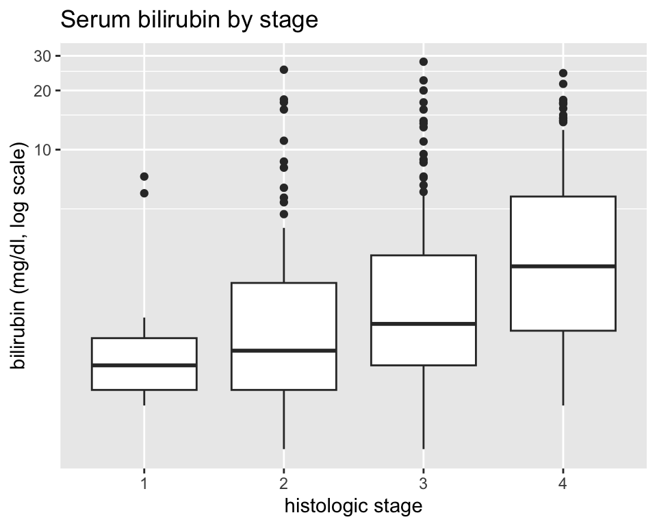

```r
q1 <- py$q1

ggplot(q1, aes(x = factor(stage), y = bili)) +
  geom_boxplot() +
  coord_transform(y = "log10") +
  labs(title = "Serum bilirubin by stage",
       x = "histologic stage", y = "bilirubin (mg/dl, log scale)")
```

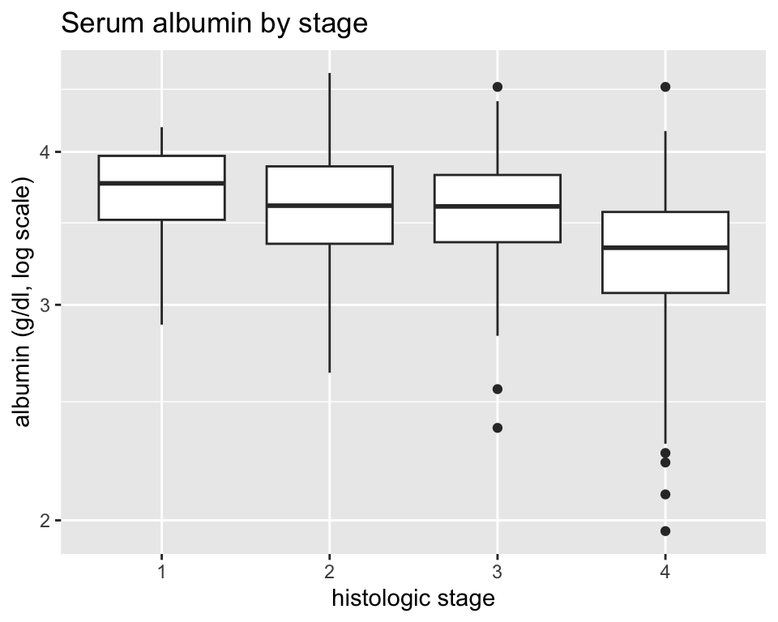

```r
ggplot(q1, aes(x = factor(stage), y = albumin)) +
  geom_boxplot() +
  coord_transform(y = "log10") +
  labs(title = "Serum albumin by stage",
       x = "histologic stage", y = "albumin (g/dl, log scale)")
```

# Question 2: are bilirubin or albumin prognostic biomarkers?

## Quartiles and death rates (R)

Patients are split into quartiles of each biomarker (Q1 = lowest) and the proportion who died (status == 2) is computed within each quartile.

```r
q2 <- pbc %>%
  select(id, status, time, bili, albumin) %>%
  mutate(
    died = status == 2,
    bili_group = factor(paste0("Q", ntile(bili, 4))),
    alb_group  = factor(paste0("Q", ntile(albumin, 4)))
  )

bili_rate <- q2 %>%
  group_by(bili_group) %>%
  summarise(died = mean(died, na.rm = TRUE))
bili_rate
```

```
## # A tibble: 4 × 2
##   bili_group  died
##   <fct>      <dbl>
## 1 Q1         0.133
## 2 Q2         0.238
## 3 Q3         0.452
## 4 Q4         0.721
```

```r
alb_rate <- q2 %>%
  group_by(alb_group) %>%
  summarise(died = mean(died, na.rm = TRUE))
alb_rate
```

```
## # A tibble: 4 × 2
##   alb_group  died
##   <fct>     <dbl>
## 1 Q1        0.590
## 2 Q2        0.4
## 3 Q3        0.25
## 4 Q4        0.298
```

## Death rate plots (Python)

The R summary tables bili_rate and alb_rate come across to Python as r.bili_rate and r.alb_rate.

```python
bili_rate = r.bili_rate.set_index("bili_group")["died"]
alb_rate  = r.alb_rate.set_index("alb_group")["died"]

fig, axes = plt.subplots(1, 2, figsize=(10, 4), sharey=True)

bili_rate.plot(kind="bar", ax=axes[0])
axes[0].set_title("Death rate by bilirubin quartile")
axes[0].set_xlabel("bilirubin quartile (Q1 = lowest)")
axes[0].set_ylabel("proportion died")

alb_rate.plot(kind="bar", ax=axes[1])
axes[1].set_title("Death rate by albumin quartile")
axes[1].set_xlabel("albumin quartile (Q1 = lowest)")

axes[0].set_ylim(0, 1)
```

```
## (0.0, 1.0)
```

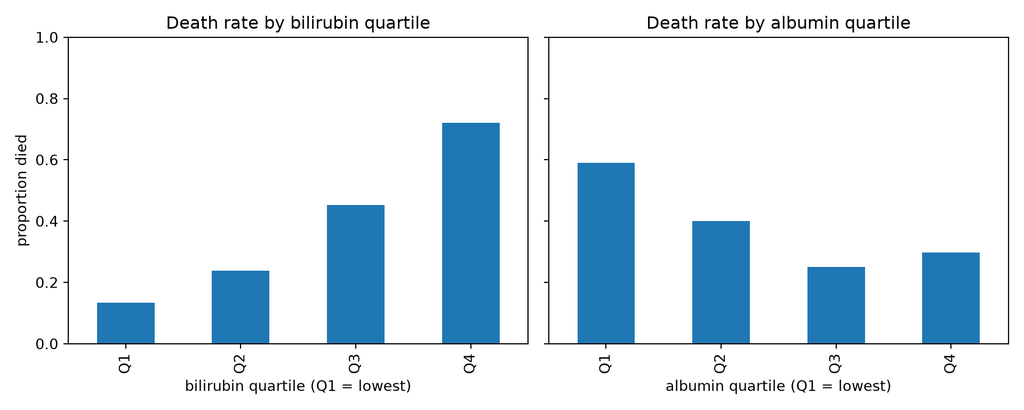

```python
plt.tight_layout()
plt.show()
```

# Analysis of data statement

Based on the analysis we see that bilirubin increases by PBC stage, while albumin stays relatively steady at each PBC stage. Death rate was determined by finding the status of those who have been declared dead, splitting bilirubin/albumin into quartiles and then finding the proportion of those who died in each quartile. Based on the data we see that as bilirubin increases the rate of death increases, while the inverse is true for albumin, with declining death rates as albumin increases.